# Claude로 하는 요약

## 들어가며

요약은 방대한 텍스트를 핵심 정보는 유지하면서 짧고 소화하기 쉬운 형태로 압축하는, 자연어 처리의 중요한 작업입니다. 정보가 넘쳐나는 오늘날, 긴 문서에서 핵심을 빠르게 뽑아내고 종합하는 능력은 여러 산업과 응용에서 대단히 값집니다.

이 가이드는 요약에 Claude의 역량을 활용하는 데 초점을 맞추며, 특히 법률 문서를 다룹니다. 법률 문서는 길고 읽기 지루한 경우가 많습니다. 깨알 같은 조항과 법률 용어가 가득할 때는 더욱 그렇습니다. 이런 문서를 효과적으로 요약하는 기법, 요약 품질을 평가하는 방법, 요약 성능을 체계적으로 개선하는 전략을 살펴봅니다.

다루는 핵심 내용은 다음과 같습니다.

- 요약을 위한 효과적인 프롬프트 작성
- 문서에서 특정 메타데이터 추출하기
- 일반적인 토큰 한도를 넘는 긴 문서 다루기
- 자동화된 방법으로 요약 품질 평가하기(예: ROUGE 점수와 [Promptfoo](https://www.promptfoo.dev/) 커스텀 방식)
- 요약 성능을 반복적으로 개선하기
- 요약 워크플로를 최적화하는 종합적인 팁

이 가이드를 마치면 Claude로 요약 작업을 구현하고 다듬는 방법을 확실히 이해하게 되고, 이 기법들을 여러분의 구체적인 사용 사례에 적용할 틀을 갖추게 됩니다.

시작하기 전에 이 가이드의 평가에 대해 짚고 넘어갈 필요가 있습니다. 요약 품질을 평가하는 일은 악명 높게 어렵습니다. 다른 여러 자연어 처리 작업과 달리 요약 평가에는 명확하고 객관적인 지표가 없는 경우가 많습니다. 평가 과정이 매우 주관적일 수 있고, 읽는 사람마다 요약의 다른 측면을 중시합니다. ROUGE 점수 같은 전통적인 경험적 방법은 유용하지만 일관성, 사실 정확성, 관련성 같은 미묘한 측면을 담아내는 데 한계가 있습니다. 게다가 "최고의" 요약은 구체적인 사용 사례, 대상 독자, 원하는 상세 수준에 따라 달라집니다. 이런 어려움에도 불구하고 이 가이드에서는 자동 지표, 정규식, 작업별 기준을 결합해 활용할 수 있는 여러 접근법을 살펴봅니다. 가장 효과적인 접근은 당면한 요약 작업에 맞춰 여러 기법을 조합하는 것임을 이 가이드에서 인정하고 출발합니다.

## 목차

1. 준비
2. 데이터 준비
3. 기본 요약
4. 멀티샷 기본 요약
5. 고급 기법
   - 가이드 요약
   - 도메인 특화 가이드 요약
   - 메타 요약
6. 요약 색인 문서: 고급 RAG 접근법
   - 요약 RAG 모범 사례
7. 평가
8. 반복적 개선
9. 마무리와 모범 사례

## 준비

이 가이드를 따라 하려면 다음 패키지를 설치해야 합니다.

- anthropic
- pypdf
- pandas
- matplotlib
- sklearn
- numpy
- rouge-score
- nltk
- seaborn
- [promptfoo](https://www.promptfoo.dev/) (평가용)

Claude API 키도 필요합니다.

필요한 패키지를 설치하고 환경을 설정하는 것부터 시작하겠습니다:

```python
# install packages
!pip install anthropic pypdf pandas matplotlib numpy rouge-score nltk seaborn --quiet
```

```python
import re

import anthropic
import matplotlib.pyplot as plt
import numpy as np
import pandas as pd
import seaborn as sns

# Set up Anthropic client
# You can set up a .env file with your API key to keep it private, and import it like so:
# from dotenv import load_dotenv
# load_dotenv()

# or add your key directly
api_key = "ANTHROPIC_API_KEY"  # Replace ANTHROPIC_API_KEY with your actual API key
client = anthropic.Anthropic(api_key=api_key)

print("Setup complete!")
```

```
Setup complete!
```

## 데이터 준비

문서를 요약하기 전에 데이터를 준비해야 합니다. PDF에서 텍스트를 추출하고, 텍스트를 정리하고, 언어 모델에 넣을 수 있는 상태로 만드는 과정입니다. 이 데모에서는 [sec.gov 웹사이트에 공개된 전대차 계약서](https://www.sec.gov/Archives/edgar/data/1045425/000119312507044370/dex1032.htm)를 사용했습니다.

시험해 보고 싶은 PDF가 있다면 이 디렉터리로 가져온 뒤 아래 파일 경로를 바꾸세요. **복사·붙여넣기로 텍스트 덩어리를 쓰고 싶다면 이 단계를 건너뛰고 `text = <텍스트 덩어리>`를 정의하세요.**

이 과정을 처리하는 함수들은 다음과 같습니다:

```python
import re

import pypdf

pdf_path = "data/Sample Sublease Agreement.pdf"


def extract_text_from_pdf(pdf_path):
    with open(pdf_path, "rb") as file:
        reader = pypdf.PdfReader(file)
        text = ""
        for page in reader.pages:
            text += page.extract_text() + "\n"
    return text


def clean_text(text):
    # Remove extra whitespace
    text = re.sub(r"\s+", " ", text)
    # Remove page numbers
    text = re.sub(r"\n\s*\d+\s*\n", "\n", text)
    return text.strip()


def prepare_for_llm(text, max_tokens=180000):
    # Truncate text to fit within token limit (approximate)
    return text[: max_tokens * 4]  # Assuming average of 4 characters per token


def get_llm_text(path):
    extracted_text = extract_text_from_pdf(path)
    cleaned_text = clean_text(extracted_text)
    llm_ready_text = prepare_for_llm(cleaned_text)
    return llm_ready_text


# You can now use get_llm_text in your LLM prompt
text = get_llm_text(pdf_path)
print(text[:500])
```

```
EX-10.32 7 dex1032.htm SUBLEASE AGREEMENT Exhibit 10.32 SUBLEASE AGREEMENT THIS SUBLEASE AGREEMENT (“Sublease ”), is dated as of April 1, 2006, by and between COHEN BROTHERS, LLC d/b/a COHEN & COMP ANY (“Sublessor ”) and TABERNA CAPIT AL MANAGEMENT , LLC (“Sublessee ”), collectively , the “ Parties …
```

이렇게 하면 PDF 문서를 손쉽게 처리해 요약할 준비를 갖출 수 있습니다. 다음 절에서는 기본 요약 방식으로 시작해 점점 더 고급 기법을 쌓아 올립니다.

## 기본 요약

Claude를 사용하는 간단한 요약 함수부터 시작해 보겠습니다. 위 문서의 텍스트를 Claude로 요약하는 단순한 시도입니다. 가이드를 진행하며 이 방법을 개선해 나갑니다.

한 가지 짚고 넘어갈 점은, 기본적으로 보이지만 이미 Claude의 중요한 기능을 쓰고 있다는 것입니다. 눈여겨볼 부분은 assistant 역할과 정지 시퀀스의 사용입니다. assistant 서두가 `<summary>`라는 마지막 구절 바로 뒤에 요약을 이어 쓰도록 Claude를 유도합니다. 그리고 정지 시퀀스 `</summary>`가 생성을 멈추라고 Claude에 알려 줍니다. 이 가이드 전반에서 계속 사용할 패턴입니다.

```python
def basic_summarize(text, max_tokens=1000):
    # Prompt the model to summarize the text
    prompt = f"""Summarize the following text in bullet points. Focus on the main ideas and key details:
    {text}
    """

    response = client.messages.create(
        model="claude-sonnet-4-6",
        max_tokens=max_tokens,
        system="You are a legal analyst known for highly accurate and detailed summaries of legal documents.",
        messages=[
            {"role": "user", "content": prompt},
            {
                "role": "assistant",
                "content": "Here is the summary of the legal document: <summary>",
            },
        ],
        stop_sequences=["</summary>"],
    )

    return response.content[0].text
```

```python
basic_response = basic_summarize(text, max_tokens=1000)

print(basic_response)
```

```
Key Points:
•Between parties: COHEN BROTHERS, LLC d/b/a COHEN & COMPANY (Sublessor) and TABERNA CAPITAL MANAGEMENT, LLC (Sublessee).
•Signed on April 1, 2006.
•Premises: 2,000 square feet of office space in Suite 1703 in the Cira Center at 2929 Arch Street, Philadelphia.

Major Terms:
•Term: 5 years starting April 1, 2006
•Payment: Fixed rent increases annually from $34.50/sf to $37.34/sf over the term.
•Utilities: Tenant pays for electricity and pro rata share of building expenses.
•Use: General office use only.
•Assignment/Subletting: Requires prior written consent of landlord.

Key Obligations:
•Tenant must maintain insurance including liability and property insurance.
•Tenant responsible for interior maintenance/condition of the premises.
•Tenant must comply with all building rules and regulations.
•Tenant must maintain premises in good order and repair.

Notable Provisions:
•Sublessor can recapture premises if tenant tries to assign/sublet without proper consent.
•Default provisions give sublessor multiple remedies including termination and accelerated rent.
•Tenant must indemnify landlord for claims related to tenant's use or actions.
•Tenant responsible for maintaining and repairing interior of premises.

This appears to be a fairly standard commercial office sublease with typical provisions regarding tenant obligations, insurance requirements, default remedies, etc. The sublessor retains significant control and remedies while the sublessee has standard obligations for an office tenant.
```

이 기본 접근법은 간단한 요약을 제공하지만, 법률이나 재무 문서에 필요한 미묘한 부분을 모두 담지 못할 수 있습니다. 위 셀을 다시 실행해 보면 알겠지만 표준화되고 정형화된 출력이 없습니다. 대신 파싱할 만한 구조 없이 문서의 기본적인 요약만 받게 됩니다. 그래서 읽기 어렵고, 신뢰하기 어려우며(무언가를 놓치지 않았다고 어떻게 알까요?), 실제 상황에서 쓰기도 까다롭습니다.

프롬프트를 손봐서 더 구조화된 요약을 얻을 수 있는지 살펴보겠습니다.

## 멀티샷 기본 요약

방대한 문서를 이렇게 빨리 요약할 수 있다는 것도 멋지지만, 더 잘할 수 있습니다. 더 고급 기법으로 넘어가기 전에, 프롬프트에 예시를 몇 개 추가해 출력을 개선하고 어느 정도 구조를 만들어 보겠습니다.

여기서 요청의 실제 형식을 크게 바꾸지는 않았지만 두 가지를 덧붙였습니다.

1. 모델에 "서두를 붙이지 말라"고 알려 줬습니다. Claude를 써 보셨다면 익숙할 그 대화체 도입부 없이 원하는 답만 나오도록 출력을 제약할 때 좋은 방법인 경우가 많습니다. 프롬프트 안에 다른 "지시"를 두지 않을 때 특히 중요합니다(뒤에서는 그런 지시를 쓰기도 합니다).
2. 요약된 문서 예시 세 개를 덧붙였습니다. 퓨샷 또는 멀티샷 러닝이라 부르며, 모델이 우리가 무엇을 원하는지 이해하는 데 도움이 됩니다.

출력이 어떻게 달라지는지 살펴보겠습니다:

```python
# We import from our data directory to save space in our notebook
from data.multiple_subleases import document1, document2, document3, sample1, sample2, sample3


def basic_summarize_multishot(text, max_tokens=1000):
    # Prompt the model to summarize the text
    prompt = f"""Summarize the following text in bullet points. Focus on the main ideas and key details:
        {text}

    Do not preamble.

    Use these examples for guidance in summarizing:

    <example1>
        <original1>
            {document1}
        </original1>

        <summary1>
            {sample1}
        </summary1>
    </example1>

    <example2>
        <original2>
            {document2}
        </original2>

        <summary2>
            {sample2}
        </summary2>
    </example2>

    <example3>
        <original3>
            {document3}
        </original3>

        <summary3>
            {sample3}
        </summary3>
    </example3>
    """

    response = client.messages.create(
        model="claude-sonnet-4-6",
        max_tokens=max_tokens,
        system="You are a legal analyst known for highly accurate and detailed summaries of legal documents.",
        messages=[
            {"role": "user", "content": prompt},
            {
                "role": "assistant",
                "content": "Here is the summary of the legal document: <summary>",
            },
        ],
        stop_sequences=["</summary>"],
    )

    return response.content[0].text
```

```python
basic_multishot_response = basic_summarize_multishot(text, max_tokens=1000)

print(basic_multishot_response)
```

```
Description: This is a sublease agreement between Cohen Brothers, LLC (Sublessor) and Taberna Capital Management, LLC (Sublessee) for office space in Philadelphia.

<parties involved>
Sublessor: Cohen Brothers, LLC d/b/a Cohen & Company
Sublessee: Taberna Capital Management, LLC
Original lessor: Brandywine Cira, L.P.
</parties involved>

<property details>
Address: 2929 Arch Street, Suite 1703, Philadelphia, PA
Description: 2,000 square feet of office space with access to file space, printers, copiers, kitchen, conference rooms
Permitted use: General office use
</property details>

<term and rent>
Start date: April 1, 2006
End date: 5 years from start date
Monthly rent:
• Months 1-12: $5,750
• Months 13-24: $5,865
• Months 25-36: $5,981.67
• Months 37-48: $6,101.67
• Months 49-60: $6,223.33
</term and rent>

<responsibilities>
Utilities: Not explicitly specified
Maintenance: Not explicitly specified
Repairs: Tenant responsible for damage repairs
Insurance: Tenant required to maintain liability insurance with $3M limit and workers compensation insurance
</responsibilities>

<special provisions>
Default: Detailed events of default and remedies specified
Holdover: Double rent for unauthorized holdover period
Assignment/Subletting: Not permitted without landlord consent
Alterations: Require landlord consent
Access to services: Includes file space, copiers, conference rooms, receptionist services
</special provisions>
```

우리가 제공한 예시들을 보면 위 출력의 형식이 동일하다는 것을 알 수 있습니다 *(data/ 아래 .txt 파일 아무거나 열어 보세요)*. 흥미로운 점은, 예시의 형식을 따르라고 Claude에 명시적으로 말하지 않았는데도 알아서 따라갔다는 것입니다. 퓨샷 러닝의 힘과, Claude가 몇 개의 예시로부터 새 입력에 일반화할 수 있음을 보여 줍니다.

## 고급 요약 기법

### 가이드 요약

가이드 요약은 요약 작업에서 모델이 따라야 할 틀을 명시적으로 정의하는 방식입니다. 전부 프롬프트로 할 수 있으며, 프롬프트의 세부를 바꿔 Claude가 더 자세하거나 간결하게, 기술 용어를 더 많이 또는 적게 쓰게, 더 높거나 낮은 수준의 요약을 내놓게 이끌 수 있습니다. 법률 문서라면 특정 측면에 집중하도록 요약을 유도할 수 있습니다.

참고로, 아래에서 보여 줄 형식화된 출력은 (위에서 살펴본) 예시로도 비슷하게 얻을 수 있을 것입니다!

```python
def guided_legal_summary(text, max_tokens=1000):
    # Prompt the model to summarize the text
    prompt = f"""Summarize the following legal document. Focus on these key aspects:

    1. Parties involved
    2. Main subject matter
    3. Key terms and conditions
    4. Important dates or deadlines
    5. Any unusual or notable clauses

    Provide the summary in bullet points under each category.

    Document text:
    {text}

    """

    response = client.messages.create(
        model="claude-sonnet-4-6",
        max_tokens=max_tokens,
        system="You are a legal analyst known for highly accurate and detailed summaries of legal documents.",
        messages=[
            {"role": "user", "content": prompt},
            {
                "role": "assistant",
                "content": "Here is the summary of the legal document: <summary>",
            },
        ],
        stop_sequences=["</summary>"],
    )

    return response.content[0].text
```

```python
# Example usage
legal_summary = guided_legal_summary(text)
print(legal_summary)
```

```
1. Parties Involved
- Sublessor: Cohen Brothers, LLC d/b/a Cohen & Company
- Sublessee: Taberna Capital Management, LLC
- Original Landlord: Brandywine Cira, L.P. (Master Lease landlord)

2. Main Subject Matter
- Sublease agreement for Suite 1703 at Cira Centre, 2929 Arch Street, Philadelphia, PA
- 2,000 square feet of office space within the Master Premises of 13,777 rentable square feet
- Includes furniture, file space, printers, copiers, kitchen, conference room facilities and receptionist/secretarial services

3. Key Terms and Conditions
- Initial Term: 5 years from April 1, 2006
- Fixed Rent: Escalating annual rent schedule starting at $34.50/sq ft in Year 1 ($69,000 annually) up to $37.34/sq ft in Year 5 ($74,680 annually)
- Pro rata share of operating expenses and utilities
- No assignment or subletting without Sublessor's prior written consent
- Sublessee takes premises "AS IS"
- Sublessee must maintain required insurance coverage
- Default provisions for non-payment, breach of lease terms, bankruptcy, etc.

4. Important Dates/Deadlines
- Commencement Date: April 1, 2006
- Expiration Date: 5 years from Commencement Date
- Fixed Rent payable monthly in advance on 1st of each month
- 5-day grace period for late payments before default

5. Notable Clauses
- Indemnification requirements for both parties
- Holdover rent at 2x monthly rate if Sublessee remains after term ends
- Sublessor not liable for utilities/services interruption
- Sublessee responsible for any construction liens
- Confession of judgment provision
- Waiver of jury trial provision
```

이렇게 하면 문서에서 가장 관련 있는 부분을 뽑아내고 특정 항목과 중요한 조항의 함의를 이해하기가 확실히 쉬워집니다.

### 도메인 특화 가이드 요약

위의 가이드 요약 프롬프트는 어떤 문서에든 줄 수 있지만, 특정 문서 유형에 맞춰 다듬으면 훨씬 더 강력해집니다. 예를 들어 전대차 계약서를 다룬다는 것을 안다면, 그 문서 유형에 가장 관련 있는 법률 용어와 개념에 집중하도록 모델을 유도할 수 있습니다. Claude로 특정 사용 사례를 다루면서 뽑아내고 싶은 값이 무엇인지 분명히 알 때 가장 유용합니다.

전대차 계약서에 맞춰 가이드 요약 함수를 수정하는 예시입니다. 작업에 따라 요약 모델을 더 쉽게 고를 수 있도록 함수에 'model' 파라미터도 추가합니다:

```python
def guided_sublease_summary(text, model="claude-sonnet-4-6", max_tokens=1000):
    # Prompt the model to summarize the sublease agreement
    prompt = f"""Summarize the following sublease agreement. Focus on these key aspects:

    1. Parties involved (sublessor, sublessee, original lessor)
    2. Property details (address, description, permitted use)
    3. Term and rent (start date, end date, monthly rent, security deposit)
    4. Responsibilities (utilities, maintenance, repairs)
    5. Consent and notices (landlord's consent, notice requirements)
    6. Special provisions (furniture, parking, subletting restrictions)

    Provide the summary in bullet points nested within the XML header for each section. For example:

    <parties involved>
    - Sublessor: [Name]
    // Add more details as needed
    </parties involved>

    If any information is not explicitly stated in the document, note it as "Not specified". Do not preamble.

    Sublease agreement text:
    {text}

    """

    response = client.messages.create(
        model=model,
        max_tokens=max_tokens,
        system="You are a legal analyst specializing in real estate law, known for highly accurate and detailed summaries of sublease agreements.",
        messages=[
            {"role": "user", "content": prompt},
            {
                "role": "assistant",
                "content": "Here is the summary of the sublease agreement: <summary>",
            },
        ],
        stop_sequences=["</summary>"],
    )

    return response.content[0].text
```

```python
# Example usage
sublease_summary = guided_sublease_summary(text)
print(sublease_summary)
```

```
<parties involved>
- Sublessor: Cohen Brothers, LLC (d/b/a Cohen & Company)
- Sublessee: Taberna Capital Management, LLC
- Original Lessor: Brandywine Cira, L.P. (Master Lease holder)
</parties involved>

<property details>
- Address: 2929 Arch Street, Suite 1703, Philadelphia, PA
- Description: 2,000 square feet of office space in Suite 1703
- Permitted Use: General office use
- Includes: Access to file space, printers, copiers, kitchen, conference rooms, receptionist/secretarial services
</property details>

<term and rent>
- Start Date: April 1, 2006
- End Date: 5 years from commencement
- Monthly Rent: Escalating schedule starting at $5,750 in year 1 up to $6,223.33 in year 5
- Security Deposit: Not specified
</term and rent>

<responsibilities>
- Utilities: Sublessee pays proportional share of utilities and operating expenses
- Maintenance: Sublessor responsible for base building maintenance
- Insurance: Sublessee must maintain general liability and property insurance
</responsibilities>

<consent and notices>
- Landlord's Consent: Required for assignment/subletting
- Notice Requirements: All notices must be in writing and delivered to specified addresses
- Sublessor's Consent: Required for alterations, improvements, signage
</consent and notices>

<special provisions>
- Furniture: Included in lease
- Parking: Not included
- Assignment: No assignment/subletting without Sublessor's consent
- Default Remedies: Specified remedies including termination and accelerated rent
</special provisions>
```

요약의 각 섹션을 XML 태그로 출력하기로 했으므로, 이제 다음과 같이 개별적으로 파싱할 수 있습니다(JSON이나 다른 형식으로도 가능합니다):

```python
import re


def parse_sections_regex(text):
    pattern = r"<(.*?)>(.*?)</\1>"
    matches = re.findall(pattern, text, re.DOTALL)

    parsed_sections = {}
    for tag, content in matches:
        items = [item.strip("- ").strip() for item in content.strip().split("\n") if item.strip()]
        parsed_sections[tag] = items

    return parsed_sections


# Parse the sections
parsed_sections = parse_sections_regex(sublease_summary)

# Check if parsing was successful
if isinstance(parsed_sections, dict) and "parties involved" in parsed_sections:
    print("Parties involved:")
    for item in parsed_sections["parties involved"]:
        print(f"- {item}")
else:
    print("Error: Parsing failed or 'parties involved' section not found.")
    print("Parsed result:", parsed_sections)
```

```
Parties involved:
- Sublessor: Cohen Brothers, LLC (d/b/a Cohen & Company)
- Sublessee: Taberna Capital Management, LLC
- Original Lessor: Brandywine Cira, L.P. (Master Lease holder)
```

### 여러 문서의 맥락 포함하기 (메타 요약)

같은 고객과 관련된 문서가 많다면 어떻게 할까요? 청킹 방식을 쓸 수 있습니다. 문서를 작고 다루기 쉬운 청크로 나눠 각각 따로 처리한 뒤, 각 청크의 요약을 합쳐 문서 전체의 메타 요약을 만드는 기법입니다. 많은 문서를 요약하거나 아주 긴 문서 하나를 요약할 때 특히 도움이 됩니다.

다음은 그 예시입니다:

```python
from data.multiple_subleases import document1, document2, document3


def chunk_text(text, chunk_size=2000):
    return [text[i : i + chunk_size] for i in range(0, len(text), chunk_size)]


def summarize_long_document(text, max_tokens=2000):
    chunks = chunk_text(text)

    # Iterate over chunks and summarize each one
    # We use guided_legal_summary here, but you can use basic_summarize or any other summarization function
    # Note that we'll also use haiku for the interim summaries, and the 3.5 sonnet for the final summary
    chunk_summaries = [
        guided_sublease_summary(chunk, model="claude-haiku-4-5", max_tokens=max_tokens)
        for chunk in chunks
    ]

    final_summary_prompt = f"""

    You are looking at the chunked summaries of multiple documents that are all related. Combine the following summaries of the document from different truthful sources into a coherent overall summary:

    {"".join(chunk_summaries)}

    1. Parties involved (sublessor, sublessee, original lessor)
    2. Property details (address, description, permitted use)
    3. Term and rent (start date, end date, monthly rent, security deposit)
    4. Responsibilities (utilities, maintenance, repairs)
    5. Consent and notices (landlord's consent, notice requirements)
    6. Special provisions (furniture, parking, subletting restrictions)

    Provide the summary in bullet points nested within the XML header for each section. For example:

    <parties involved>
    - Sublessor: [Name]
    // Add more details as needed
    </parties involved>

    If any information is not explicitly stated in the document, note it as "Not specified".

    Summary:
    """

    response = client.messages.create(
        model="claude-sonnet-4-6",
        max_tokens=max_tokens,
        system="You are a legal expert that summarizes notes on one document.",
        messages=[
            {"role": "user", "content": final_summary_prompt},
            {
                "role": "assistant",
                "content": "Here is the summary of the legal document: <summary>",
            },
        ],
        stop_sequences=["</summary>"],
    )

    return response.content[0].text


# Example usage
# combine 3 documents (all related) together
text = document1 + document2 + document3
long_summary = summarize_long_document(text)
print(long_summary)
```

```
<parties involved>
- Sublessor: Apex Innovations, Inc. (Delaware corporation) later identified as TechHub Enterprises, LLC
- Sublessee: NanoSphere Solutions, Inc. and Quantum Dynamics, LLC (California LLC)
- Original Lessor: Innovate Properties, LLP
</parties involved>

<property details>
- Address: 9876 Innovation Park, Building C, San Francisco, CA 94107
- Description: Approximately 15,000-25,000 square feet of office and laboratory space
- Permitted Use: General office purposes, research and development, and laboratory uses consistent with BSL-2 facility requirements
</property details>

<term and rent>
- Start Date: September 1, 2023
- End Date: August 31, 2026 (with option to extend for 3-5 additional years)
- Monthly Rent: Starting at $75,000/month with annual 3% increases
- Security Deposit: $450,000-$787,500
</term and rent>

<responsibilities>
- Utilities: Sublessee responsible for all utilities and services, including electricity, gas, water, sewer, telephone, internet, and janitorial
- Maintenance: Sublessee responsible for interior maintenance, repairs and replacements, including walls, floors, ceilings, doors, windows, fixtures
</responsibilities>

<consent and notices>
- Landlord's Consent: Required for assignments, subletting, alterations
- Notice Requirements: 30 days written notice for defaults, insurance changes; 9-12 months notice for term extensions
</consent and notices>

<special provisions>
- Furniture: Right to install furniture/equipment 15-30 days before commencement
- Parking: Non-exclusive right to use common parking facilities
- Subletting Restrictions: No assignment/subletting without prior written consent, except to affiliated entities
- Additional: Hazardous materials restrictions, OFAC compliance requirements, jury trial waiver
</special provisions>
```

## 요약 색인 문서: 고급 RAG 접근법

요약 색인 문서는 문서 단위에서 동작하는 고급 검색 증강 생성(RAG) 접근법입니다.

이 방식은 특히 큰 문서를 다루거나 정확한 정보 검색이 결정적일 때 전통적인 RAG 기법보다 여러 장점을 제공합니다.

#### 동작 방식

1. 문서 요약: 코퍼스의 각 문서에 대해 간결한 요약을 생성합니다(텍스트의 일부를 질의해 빠르게 요약합니다).
2. 컨텍스트 윈도 최적화: 모든 요약이 언어 모델의 컨텍스트 윈도에 들어가도록 합니다.
3. 관련성 점수화: 각 요약이 질의와 얼마나 관련 있는지 모델에 순위를 매기게 합니다.
4. 재순위화(선택): 상위 K개 결과를 더 다듬고 압축하기 위해 재순위화 기법을 적용합니다.
5. 당면한 질의에 답합니다.

이 접근법에는 뚜렷한 장점이 있습니다.

- 전통적인 RAG 방식보다 적은 맥락으로 검색용 문서 순위를 더 효율적으로 매깁니다.
- 특정 작업에서 뛰어난 성능: 다른 RAG 방식보다 나은 결과를 내며, 올바른 문서를 일관되게 첫 번째로 올립니다.
- 최적화된 정보 검색: 재순위화가 결과를 압축해, 가장 간결하고 관련성 높은 정보만 모델에 제시되도록 합니다.

```python
class LegalSummaryIndexedDocuments:
    def __init__(self, client):
        self.client = client  # Claude client
        self.documents: list[dict[str, str]] = []  # List of docs to store
        self.summaries: list[str] = []

    def add_document(self, doc_id: str, content: str):
        # Adds a document to the index
        self.documents.append({"id": doc_id, "content": content})

    def generate_summaries(self):
        # Generates summaries for all documents in the index
        for doc in self.documents:
            summary = self._generate_legal_summary(doc["content"])
            self.summaries.append(summary)

    def _generate_legal_summary(self, content: str) -> str:
        # Note how we constrain the content to a maximum of 2000 words. We do this because we don't need that much information for the intial ranking.
        prompt = f"""
        Summarize the following sublease agreement. Focus on these key aspects:

        1. Parties involved (sublessor, sublessee, original lessor)
        2. Property details (address, description, permitted use)
        3. Term and rent (start date, end date, monthly rent, security deposit)
        4. Responsibilities (utilities, maintenance, repairs)
        5. Consent and notices (landlord's consent, notice requirements)
        6. Special provisions (furniture, parking, subletting restrictions)

        Provide the summary in bullet points nested within the XML header for each section. For example:

        <parties involved>
        - Sublessor: [Name]
        // Add more details as needed
        </parties involved>

        If any information is not explicitly stated in the document, note it as "Not specified".

        Sublease agreement text:
        {content[:2000]}...

        Summary:
        """

        response = client.messages.create(
            model="claude-sonnet-4-6",
            max_tokens=500,
            temperature=0.2,
            messages=[
                {"role": "user", "content": prompt},
                {
                    "role": "assistant",
                    "content": "Here is the summary of the legal document: <summary>",
                },
            ],
            stop_sequences=["</summary>"],
        )
        return response.content[0].text

    def rank_documents(self, query: str, top_k: int = 3) -> list[tuple[str, float]]:
        """
        Rank documents based on their relevance to the given query.
        We use Haiku here as a cheaper, faster model for ranking.
        """
        ranked_scores = []
        for summary in self.summaries:
            prompt = f"Legal document summary: {summary}\n\nLegal query: {query}\n\nRate the relevance of this legal document to the query on a scale of 0 to 10. Only output the numeric value:"

            response = client.messages.create(
                model="claude-haiku-4-5",
                max_tokens=2,
                temperature=0,
                messages=[{"role": "user", "content": prompt}],
            )
            ranked_score = float(response.content[0].text)
            ranked_scores.append(ranked_score)

        ranked_indices = np.argsort(ranked_scores)[::-1][:top_k]
        return [(self.documents[i]["id"], ranked_scores[i]) for i in ranked_indices]

    def extract_relevant_clauses(self, doc_id: str, query: str) -> list[str]:
        """
        Extracts relevant clauses from a document based on a query.
        """
        doc_content = next(doc["content"] for doc in self.documents if doc["id"] == doc_id)

        prompt = f"""
        Given the following legal query and document content, extract the most relevant clauses or sections and write the answer to the query.
        Provide each relevant clause or section separately, preserving the original legal language:

        Legal query: {query}

        Document content: {doc_content}...

        Relevant clauses or sections (separated by '---'):"""

        response = client.messages.create(
            model="claude-sonnet-4-6",
            max_tokens=1000,
            temperature=0,
            messages=[{"role": "user", "content": prompt}],
        )

        clauses = re.split(r"\n\s*---\s*\n", response.content[0].text.strip())
        return [clause.strip() for clause in clauses if clause.strip()]
```

```python
from data.multiple_subleases import document1, document2, document3

lsid = LegalSummaryIndexedDocuments(client=client)

# Add documents
lsid.add_document("doc1", document1)
lsid.add_document("doc2", document2)
lsid.add_document("doc3", document3)

# Generate summaries - this would happen at ingestion
lsid.generate_summaries()

# Rank documents for a legal query
legal_query = "What contract is for the sublessor Apex Innovations, LLC?"
ranked_results = lsid.rank_documents(legal_query)

print("Initial ranking:", ranked_results)

# Extract relevant clauses from the top-ranked document
top_doc_id = ranked_results[0][0]
relevant_clauses = lsid.extract_relevant_clauses(top_doc_id, legal_query)

print("\nRelevant clauses from the top-ranked document:")
for i, clause in enumerate(relevant_clauses[1:], 1):
    print(f"Clause {i}: {clause}")
```

```
Initial ranking: [('doc1', 8.0), ('doc3', 0.0), ('doc2', 0.0)]

Relevant clauses from the top-ranked document:
Clause 1: COMMERCIAL SUBLEASE AGREEMENT

THIS COMMERCIAL SUBLEASE AGREEMENT (hereinafter referred to as the "Sublease") is made and entered into on this 15th day of August, 2023 (the "Effective Date"), by and between:

SUBLESSOR: Apex Innovations, Inc., a Delaware corporation with its principal place of business at 1234 Tech Boulevard, Suite 5000, San Francisco, CA 94105 (hereinafter referred to as the "Sublessor")
Clause 2: WHEREAS, Sublessor is the Tenant under that certain Master Lease Agreement dated January 1, 2020 (hereinafter referred to as the "Master Lease"), wherein Innovate Properties, LLP (hereinafter referred to as the "Master Lessor") leased to Sublessor those certain premises consisting of appro…
Clause 3: Answer: There appears to be an error in the legal query. The query refers to "Apex Innovations, LLC" but the document shows that the sublessor is actually "Apex Innovations, Inc.", a Delaware corporation. The contract for Apex Innovations, Inc. is:

1. A Commercial Sublease Agreement dated August 15, 2023, where they are the Sublessor
2. A Master Lease Agreement dated January 1, 2020, where they are the Tenant under Innovate Properties, LLP
```

### 요약 RAG 모범 사례

- 최적 요약 길이: 간결함과 정보량 사이의 균형점을 찾도록 여러 요약 길이를 실험해 보세요.
- 반복적 재순위화: 특히 문서 집합이 클 때는 더 정밀한 결과를 위해 여러 차례 재순위화하는 것을 고려하세요.
- 캐싱: 반복 질의의 성능을 높이도록 요약과 초기 순위에 캐싱 메커니즘을 구현하세요.

## 평가

이 쿡북 서두에서 말했듯 요약 품질을 평가하는 일은 만만치 않습니다. 문서를 요약하는 방법이 여러 가지이고, 서로 다른 요약이 똑같이 타당할 수 있기 때문입니다. 사용 사례에 따라 요약의 어떤 측면이 더 또는 덜 중요해집니다.

프롬프트 엔지니어링에 대한 경험적 방법론은 [여기](https://docs.claude.com/en/docs/prompt-engineering)에서 더 읽어 볼 수 있습니다. 주피터 노트북은 프롬프트 엔지니어링을 시작하기에 좋지만, 데이터셋이 커지고 프롬프트가 많아질수록 함께 확장되는 도구를 활용하는 것이 중요합니다.

이 절에서는 오픈소스 LLM 평가 도구인 [Promptfoo](https://www.promptfoo.dev/)를 살펴봅니다. 시작하려면 `./evaluation` 디렉터리로 가서 `./evaluation/README.md`를 확인하세요.

평가를 성공적으로 실행했다면 여기로 돌아와 결과를 확인하세요. 결과를 만든 뒤 `npx promptfoo@latest view` 명령으로 동적으로 살펴볼 수도 있습니다.

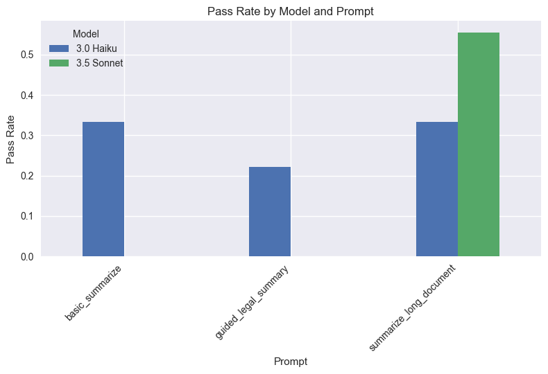

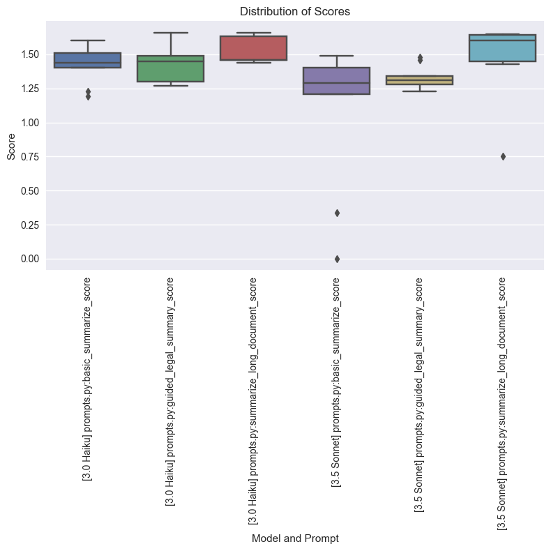

|  | [3.0 Haiku] prompts.py:basic_summarize_score | [3.0 Haiku] prompts.py:guided_legal_summary_score | [3.0 Haiku] prompts.py:summarize_long_document_score | [3.5 Sonnet] prompts.py:basic_summarize_score | [3.5 Sonnet] prompts.py:guided_legal_summary_score | [3.5 Sonnet] prompts.py:summarize_long_document_score |
| --- | --- | --- | --- | --- | --- | --- |
| count | 9.000000 | 9.000000 | 9.000000 | 9.000000 | 9.000000 | 9.000000 |
| mean | 1.423333 | 1.443333 | 1.522222 | 1.088889 | 1.330000 | 1.475556 |
| std | 0.135647 | 0.146969 | 0.092030 | 0.535547 | 0.086458 | 0.285750 |
| min | 1.190000 | 1.270000 | 1.440000 | 0.000000 | 1.230000 | 0.750000 |
| 25% | 1.400000 | 1.300000 | 1.460000 | 1.210000 | 1.280000 | 1.450000 |
| 50% | 1.440000 | 1.450000 | 1.460000 | 1.290000 | 1.310000 | 1.600000 |
| 75% | 1.510000 | 1.490000 | 1.630000 | 1.400000 | 1.340000 | 1.640000 |
| max | 1.600000 | 1.660000 | 1.660000 | 1.490000 | 1.480000 | 1.650000 |

```python
import re

import matplotlib.pyplot as plt
import pandas as pd
import seaborn as sns

%matplotlib inline
plt.style.use("seaborn")

# Load the data
df = pd.read_csv("data/results.csv")


# Function to extract PASS/FAIL and score
def extract_result(text):
    match = re.search(r"\[(PASS|FAIL)\]\s*\((\d+\.\d+)\)", str(text))
    if match:
        return match.group(1), float(match.group(2))
    return "UNKNOWN", 0.0


# Apply the extraction to relevant columns
for col in df.columns[2:]:
    df[f"{col}_result"], df[f"{col}_score"] = zip(*df[col].apply(extract_result), strict=False)

# Prepare data for grouped accuracy score
models = ["3.5 Sonnet", "3.0 Haiku"]
prompts = ["basic_summarize", "guided_legal_summary", "summarize_long_document"]

results = []
for model in models:
    for prompt in prompts:
        col = f"[{model}] prompts.py:{prompt}_result"
        if col in df.columns:
            pass_rate = (df[col] == "PASS").mean()
            results.append({"Model": model, "Prompt": prompt, "Pass Rate": pass_rate})

result_df = pd.DataFrame(results)

# 1. Grouped bar chart for accuracy scores
plt.figure(figsize=(12, 6))
result_pivot = result_df.pivot(index="Prompt", columns="Model", values="Pass Rate")
result_pivot.plot(kind="bar")
plt.title("Pass Rate by Model and Prompt")
plt.ylabel("Pass Rate")
plt.legend(title="Model")
plt.xticks(rotation=45, ha="right")
plt.tight_layout()
plt.show()

# 2. Box plot of scores
plt.figure(figsize=(8, 8))
score_cols = [col for col in df.columns if col.endswith("_score")]
score_data = df[score_cols].melt()
sns.boxplot(x="variable", y="value", data=score_data)
plt.title("Distribution of Scores")
plt.xticks(rotation=90)
plt.xlabel("Model and Prompt")
plt.ylabel("Score")
plt.tight_layout()
plt.show()

# Display summary statistics
summary_stats = df[[col for col in df.columns if col.endswith("_score")]].describe()
display(summary_stats)
```

## 반복적 개선

평가 결과를 더 들여다보면 개선의 여지가 계속 보입니다. 프롬프트 엔지니어링의 반복적인 부분이 여기서 등장합니다. 결과를 개선하기 위해 취할 수 있는 단계는 다음과 같습니다.

1. Promptfoo 결과를 분석해 강점과 약점을 찾아냅니다. 예를 들어 contains 평가가 많이 실패한 것으로 보입니다. 아마 일부 문서에 XML 태그가 요구하는 정보가 들어 있지 않기 때문일 것입니다. 성능을 정확히 평가하려면 이 평가를 다듬어야 합니다(이것은 어디까지나 예시입니다!).
2. 구체적인 문제를 해결하도록 프롬프트를 다듬습니다(예: 간결성이나 완전성 개선). 멀티샷이 첫 시도치고 아주 좋았다는 것을 확인했습니다. 성능을 더 높이려면 이를 고급 기법들과 함께 도입해야 합니다.
3. 긴 문서에 대해 다양한 청킹 전략을 실험합니다.
4. temperature와 max_tokens 파라미터를 미세 조정합니다.
5. 요약 품질을 높이는 후처리 단계를 구현합니다.

## 마무리와 모범 사례

이 가이드에서는 법률 문서를 중심으로 Claude로 문서를 요약하는 다양한 기법을 다뤘습니다. 완벽한 요약 시스템과 평가 프레임워크를 만드는 일은 하나의 기술입니다. 성공하려면 이 방법들을 조합해야 합니다. 처음에 말했듯 요약은 매우 주관적인 주제지만, 그럼에도 실현 가능한 평가 방법을 찾아 결과에 만족할 만한 수준까지 왔습니다. 그리고 늘 기억하세요. 여러분은 100% 정확도를 기준으로 삼는 것이 아니라, 이 복잡한 작업을 여러분이 직접 얼마나 잘 해낼 수 있는가를 기준으로 삼는 것입니다. 이 가이드에서 보여 준 Claude의 속도와 효율을 감안하면, 이런 방법론적 접근의 진짜 이점을 깨닫게 되고 정작 중요한 의사결정에 시간을 쓸 수 있게 됩니다.

마지막으로 염두에 둘 모범 사례를 정리했습니다.

1. 명확하고 구체적인 프롬프트를 작성하세요. "서두를 붙이지 말라" 같은 표현으로 출력을 제약하세요.
2. 예시를 최소 2개는 사용하세요.
3. 도메인 특화 문서에는 가이드 요약을 사용하세요.
4. 긴 문서에는 효과적인 고급 전략을 도입하세요.
5. 주기적으로 평가하고 접근법을 다듬으세요.
6. AI가 생성한 요약의 윤리적 함의와 한계를 고려하세요.